# EP06 Grupo 9

2024-10-24

# Enunciado: En este momento, los investigadores buscan determinar si existen diferencias en el tiempo que tardan los usuarios en formular consultas para problemas con diferente nivel de dificultad en el área de arquitectura.

- Hipótesis nula: No existen diferencias en el tiempo que tardan los usuarios en formular consultas para problemas con diferente nivel de dificultad en el área de arquitectura.(H0: μBaja = μMedia = μAlta)
- Hipótesis alternativa: Existen diferencias en el tiempo que tardan los usuarios en formular consultas para problemas con diferente nivel de dificultad en el área de arquitectura.(HA: μBaja ≠ μMedia v μBaja ≠ μAlta v μMedia ≠ μAlta)

Además, asumamos un nivel de significancia de alfa = 0.01.

## Verificación de condiciones

#### 1) La escala con que se mide la variale dependiente tiene las propuedades de una escala de intervalos iguales.

- Lo anterior se cumple ya que el tiempo que tardan los usuarios en formular consultas es una variable continua y se mide en minutos, lo que significa que la diferencia entre 1 y 2 minutos es la misma que entre 2 y 3 minutos.

#### 3) Se puede suponer que la población de cada grupo sigue una distribución normal.

- Para responder lo anterior, se realizá un gráfico Q-Q plot para verificar si los datos siguen una distribución normal.

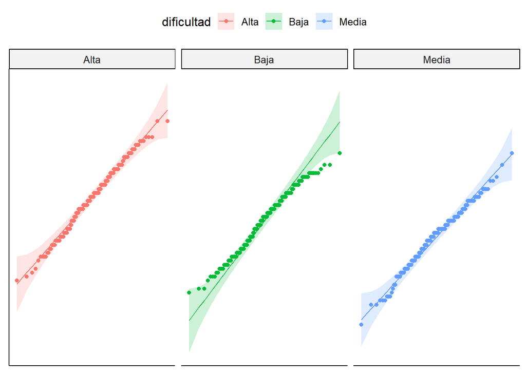

```r
datos <- read.csv("EP06 Datos.csv")
datos <- datos %>% filter(area == "Arquitectura")

dificultad_alta <- datos %>% filter(dificultad == "Alta")
dificultad_media <- datos %>% filter(dificultad == "Media")
dificultad_baja <- datos %>% filter(dificultad == "Baja")


# Aplico gráficos Q-Q
g <- ggqqplot(datos, x = "tiempo", y = "dificultad", color = "dificultad")
g <- g + facet_wrap(~ dificultad)
g <- g + rremove("x.ticks") + rremove("x.text")
g <- g + rremove("y.ticks") + rremove("y.text")
g <- g + rremove("axis.title")

print(g)
```

* Dado los resultados obtenidos por los gráficos Q-Q, se puede asumir que, aunque la distribución de la dificultad baja tiene algunos valores atípicos que escapan de la normal, se puede asumir que es aproximadamente normal. Para ahondar más en comprobar la normalidad de los datos, se puede realizar una prueba de Shapiro-Wilk.

```r
normalidad_baja <- shapiro.test(dificultad_baja$tiempo)
normalidad_media <- shapiro.test(dificultad_media$tiempo)
normalidad_alta <- shapiro.test(dificultad_alta$tiempo)

cat("Prueba de Shapiro-Wilk para dificultad baja: ", normalidad_baja$p.value, "\n")
```

```
## Prueba de Shapiro-Wilk para dificultad baja:  0.02696269
```

```r
cat("Prueba de Shapiro-Wilk para dificultad media: ", normalidad_media$p.value, "\n")
```

```
## Prueba de Shapiro-Wilk para dificultad media:  0.08824075
```

```r
cat("Prueba de Shapiro-Wilk para dificultad alta: ", normalidad_alta$p.value, "\n")
```

```
## Prueba de Shapiro-Wilk para dificultad alta:  0.4724114
```

- Con los test de Shapiro-Wilk se puede concluir que los datos de los tres niveles de dificultad siguen una distribución normal, ya que los p-values obtenidos son mayores a nuestro nivel de significancia.

#### 4) La matriz de covarianzas es esférica.

- Para verificar si la matriz de covarianzas es esférica, se puede realizar una prueba de esfericidad de Mauchly. Para lo anterior se puede utilizar la función ezANOVA.

```r
# Prueba de Esfericidad con ezANOVA
instancia <- factor(1:200)
Alta <- c(dificultad_alta$tiempo)
Media <- c(dificultad_media$tiempo)
Baja <- c(dificultad_baja$tiempo)
datos <- data.frame(instancia, Alta, Media, Baja)

datos <- datos %>% pivot_longer(c("Alta", "Media", "Baja"), names_to = "dificultad", values_to = "tiempo")

datos[["dificultad"]] <- factor(datos[["dificultad"]])


prueba <- ezANOVA(data = datos, dv = tiempo, wid = instancia, within = dificultad, return_aov = TRUE)

print(prueba[["Mauchly's Test for Sphericity"]])
```

```
##       Effect         W         p p<.05
## 2 dificultad 0.9936533 0.5324159
```

- De lo anterior se puede concluir que la matriz de covarianzas es esferica, por el p-value obtenido en la prueba de Mauchly (p-value 0.53).

## Prueba ANOVA

- Por eso, podemos usar un ANOVA para mmuestras correlacionadas

```r
# ANOVA para muestras correlacionadas
print(summary(prueba[["aov"]]))
```

```
##
## Error: instancia
##            Df Sum Sq Mean Sq F value Pr(>F)
## Residuals 199  13043   65.54
##
## Error: instancia:dificultad
##             Df Sum Sq Mean Sq F value Pr(>F)
## dificultad   2   9228    4614   88.64 <2e-16 ***
## Residuals  398  20718      52
## ---
## Signif. codes:  0 '***' 0.001 '**' 0.01 '*' 0.05 '.' 0.1 ' ' 1
```

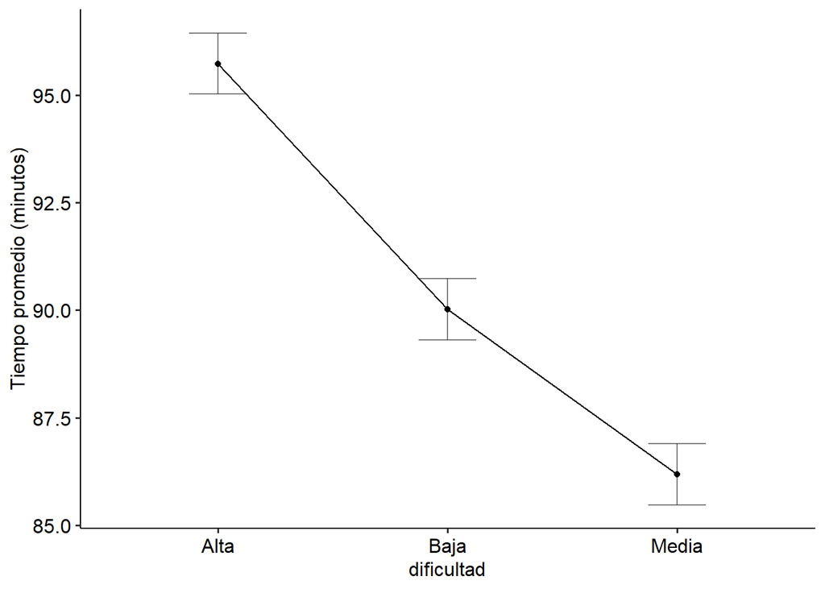

```r
# Hacemos un gráfico del tamaño del efecto
g2 <- ezPlot(data = datos, dv = tiempo, wid = instancia, within = dificultad, y_lab = "Tiempo promedio (minutos)", x = dificultad)
g2 <- g2 + theme_pubr()

print(g2)
```

## Post-hoc

- Para determinar cuáles son las diferencias significativas, se puede realizar un test post-hoc de Tukey.

```r
# Test de Tukey
mixto <- lme(tiempo ~ dificultad, data = datos, random = ~1|instancia)
medias <- emmeans(mixto, "dificultad")
tukey <- pairs(medias, adjust = "tukey")

print(tukey)
```

```
##  contrast     estimate    SE  df t.ratio p.value
##  Alta - Baja      5.71 0.721 398   7.914  <.0001
##  Alta - Media     9.54 0.721 398  13.229  <.0001
##  Baja - Media     3.83 0.721 398   5.315  <.0001
##
## Degrees-of-freedom method: containment
## P value adjustment: tukey method for comparing a family of 3 estimates
```

- Del procedimiento post-hoc realizado, se puede concluir que todas las diferencias son significativas, ya que todas tienen un p-value menor a 0.01. Es decir, el tiempo que tardan los usuarios en formular consultas para problemas con diferente nivel de dificultad en el área de arquitectura es significativamente diferente en todos los niveles de dificultad.